# Rorcid databasing

Abstract

Case study from the pre-conference workshop “Introduction to R” at the 2020 Munin Conference on Scholarly Publishing.

https://site.uit.no/muninconf/pre-conference-workshop/

# Introduction

This page is automatically generated by harvesting information from [ORCID.org](http://orcid.org). Starting with a list of maths researchers with ORCIDs we can curate a list of recent publications.

This is a bit rough around the edges, but should provide for a useful case-study. You will need to install several packages - see file `install.R`.

# Publication metadata analysis with R

## Who do we have in the database?

We start by reading in the database of ORCID identifiers. You are welcome to use your own CSV file here, for example with ORCIDs from your own institution. The only mandatory column is `orcid`.

```r
maths_csv <- read.csv("maths_orcid.csv", comment.char = '#')
##print(xtable(damtp.csv), type="html")
orcids <- as.character(maths_csv$orcid)
orcids <- orcids[nchar(orcids)>0]  # not everyone has an orcid
print(orcids)
```

```
##  [1] "0000-0003-4635-6830" "0000-0002-3170-9480" "0000-0001-9456-4840"
##  [4] "0000-0002-8487-2038" "0000-0001-8607-8025" "0000-0002-7495-5040"
##  [7] "0000-0002-5869-7723" "0000-0002-7726-6988" "0000-0001-5055-9513"
## [10] "0000-0003-2624-3687" "0000-0002-5333-099X" "0000-0002-2505-8175"
## [13] "0000-0002-6883-6168" "0000-0002-3284-5169" "0000-0002-7756-1944"
## [16] "0000-0001-8346-3219" "0000-0002-4894-5674" "0000-0003-1363-6369"
## [19] "0000-0003-0099-6306" "0000-0002-3134-7088" "0000-0002-3716-4952"
## [22] "0000-0001-6568-988X"
```

We have 22 records in the data base. (Note that the number in the previous sentence is not hardcoded in the document, it is the result of some inline R computation.)

## Interrogate rorcid

Starting with just the ORCIDs, we can get some information such as names, and DOIs associated with each user.

When you run the following code chunk for the first time, the package `rorcid` will open a browser windows so you can log in on the ORCID website and you can query the ORCID API as an authenticated user. You can manually trigger this by calling `rorcid::orcid_auth()`.

```r
get_orcid_info <- function(orcid_num) {
  info <- rorcid::orcid_id(orcid = orcid_num)
  given <- info[[1]]$name$`given-names`$value
  family <- info[[1]]$name$`family-name`$value
  works <- rorcid::works(orcid_num)
  my_dois <- rorcid::identifiers(works)
  num_dois <- length(my_dois)

  list(orcid = orcid_num,
       given = given,
       family = family,
       num_dois = num_dois,
       dois = my_dois)

}

results <- lapply(orcids, get_orcid_info)
```

Now we convert these results into a friendly form of a data frame.

```r
given <- sapply(results, function(x) x$given)
family <- sapply(results, function(x) x$family)
orcid <- sapply(results, function(x) x$orcid)
doi_n <- sapply(results, function(x) x$num_dois)

results_df <- data.frame(orcid = orcid, given = given, family = family, doi_n = doi_n)
results_df
```

## Distribution of DOIs associated with each user.

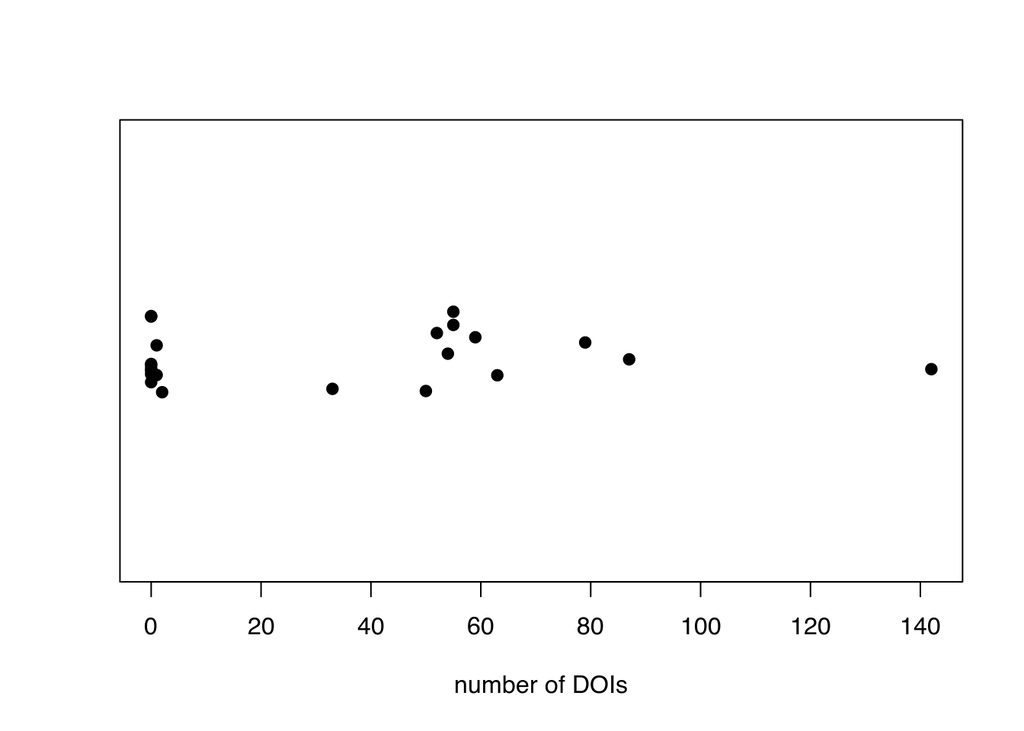

```r
stripchart(results_df$doi_n, method = "jitter", pch = 19, xlab = "number of DOIs")
```

## Interactive table of outputs

We use the function `datatable` from the package `DT` to create a paginated searchable table in the HTML output of this document.

```r
df <-results_df
id1 <- unlist(df$orcid)
url <- sprintf('<a href="http://orcid.org/%s">%s</a>', id1, id1)
df$orcid <- url
DT::datatable(df, escape = 1, options = list(pageLength = 25))
```

|  | orcid | given | family | doi_n |
| --- | --- | --- | --- | --- |
| 1 | 0000-0003-4635-6830 | Benjamin | Allanach | 142 |
| 2 | 0000-0002-3170-9480 | Colm-cille | Caulfield | 87 |
| 3 | 0000-0001-9456-4840 | Stephen | Cowley | 0 |
| 4 | 0000-0002-8487-2038 | Stuart | Dalziel | 63 |
| 5 | 0000-0001-8607-8025 | Stephen | Eglen | 59 |
| 6 | 0000-0002-7495-5040 | James | Ferguson | 0 |
| 7 | 0000-0002-5869-7723 | Michael | Green | 0 |
| 8 | 0000-0002-7726-6988 | Peter | Haynes | 55 |
| 9 | 0000-0001-5055-9513 | Richard | Jozsa | 2 |
| 10 | 0000-0003-2624-3687 | Adrian | Kent | 0 |

[output cut: 12 more lines]

## Example listings

```r
dois = c() # the vector of dois
for (i in 1:nrow(df)) {
  doi_n = df[i,"doi_n"]
  if ( doi_n > 0 ) { # check if entry has a DOI
    dois = c(dois, results[[i]]$dois[1:(min(2, doi_n))])
  }
}
##dois = grab.info[[4]]$dois[1:3]
bibentries <- RefManageR::GetBibEntryWithDOI(dois)
```

```
## unable to retrieve bibliographic data for the following supplied DOIs: '10.1103/PhysRevLett.125.161601', '10.1017/jfm.2020.720', '10.1017/jfm.2019.357', '10.1017/jfm.2020.483', '10.1063/1.4922317', '10.12688/f1000research.18238.1'
```

```r
print(bibentries)
```

Allanach, B. C, B. Gripaios, and J. Tooby-Smith (2020). “Geometric general solution to the U(1) anomaly equations”. In: *Journal of High Energy Physics* 2020.5. DOI: [10.1007/jhep05(2020)065](https://doi.org/10.1007%2Fjhep05%282020%29065). URL: https://doi.org/10.1007/jhep05(2020)065.

Cooper, L. J, C. T. Davies, J. Harrison, J. Komijani, and M. W. and (2020). “Bc$\rightarrow$Bs(d) form factors from lattice QCD”. In: *Physical Review D* 102.1. DOI: [10.1103/physrevd.102.014513](https://doi.org/10.1103%2Fphysrevd.102.014513). URL: https://doi.org/10.1103/physrevd.102.014513.

Cope, L, P. Garaud, and C. P. Caulfield (2020). “The dynamics of stratified horizontal shear flows at low Péclet number”. In: *Journal of Fluid Mechanics* 903. DOI: [10.1017/jfm.2020.600](https://doi.org/10.1017%2Fjfm.2020.600). URL: https://doi.org/10.1017/jfm.2020.600.

Davies, C. T, J. Harrison, G. P. Lepage, C. J. Monahan, J. Shigemitsu, and M. W. and (2020). “Lattice QCD Matrix Elements for the Bs0-B Width Difference beyond Leading Order”. In: *Physical Review Letters* 124.8. DOI: [10.1103/physrevlett.124.082001](https://doi.org/10.1103%2Fphysrevlett.124.082001). URL: https://doi.org/10.1103/physrevlett.124.082001.

Eglen, S. and E. Lieungh (2020). “Open Code and Peer Review”. In: *Open Science Talk*. DOI: [10.7557/19.5311](https://doi.org/10.7557%2F19.5311). URL: https://doi.org/10.7557/19.5311.

Freitas, G. B. de and H. S. Reall (2014). “Algebraically special solutions in AdS/CFT”. In: *Journal of High Energy Physics* 2014.6. DOI: [10.1007/jhep06(2014)148](https://doi.org/10.1007%2Fjhep06%282014%29148). URL: https://doi.org/10.1007/jhep06(2014)148.

Hebenstreit, M, R. Jozsa, B. Kraus, and S. Strelchuk (2020). “Computational power of matchgates with supplementary resources”. In: *Physical Review A* 102.5. DOI: [10.1103/physreva.102.052604](https://doi.org/10.1103%2Fphysreva.102.052604). URL: https://doi.org/10.1103/physreva.102.052604.

Hewitt, D. R, J. A. Neufeld, and N. J. Balmforth (2015). “Shallow, gravity-driven flow in a poro-elastic layer”. In: *Journal of Fluid Mechanics* 778, pp. 335-360. DOI: [10.1017/jfm.2015.361](https://doi.org/10.1017%2Fjfm.2015.361). URL: https://doi.org/10.1017/jfm.2015.361.

Heydecker, D, G. Maierhofer, A. I. Aviles-Rivero, Q. Fan, D. Chen, C. Schonlieb, and S. Susstrunk (2019). “Mirror, Mirror, on the Wall, Who’s Got the Clearest Image of Them All?—A Tailored Approach to Single Image Reflection Removal”. In: *IEEE Transactions on Image Processing* 28.12, pp. 6185-6197. DOI: [10.1109/tip.2019.2923559](https://doi.org/10.1109%2Ftip.2019.2923559). URL: https://doi.org/10.1109/tip.2019.2923559.

Howland, C. J, J. R. Taylor, and C. P. Caulfield (2020). “Mixing in forced stratified turbulence and its dependence on large-scale forcing”. In: *Journal of Fluid Mechanics* 898. DOI: [10.1017/jfm.2020.383](https://doi.org/10.1017%2Fjfm.2020.383). URL: https://doi.org/10.1017/jfm.2020.383.

Kimanius, D, G. Zickert, T. Nakane, J. Adler, S. Lunz, C. Schönlieb, O. Öktem, et al. (2020). “Exploiting prior knowledge about biological macromolecules in cryo-EM structure determination”.

DOI: [10.1101/2020.03.25.007914](https://doi.org/10.1101%2F2020.03.25.007914). URL: https://doi.org/10.1101/2020.03.25.007914.

Lynch, E. M. and G. I. Ogilvie (2020). “Dynamical structure of highly eccentric discs with applications to tidal disruption events”. In: *Monthly Notices of the Royal Astronomical Society*. DOI: [10.1093/mnras/staa3459](https://doi.org/10.1093%2Fmnras%2Fstaa3459). URL: https://doi.org/10.1093/mnras/staa3459.

McKenna, C. M, T. J. Bracegirdle, E. F. Shuckburgh, P. H. Haynes, and M. M. Joshi (2018). “Arctic Sea Ice Loss in Different Regions Leads to Contrasting Northern Hemisphere Impacts”. In: *Geophysical Research Letters* 45.2, pp. 945-954. DOI: [10.1002/2017gl076433](https://doi.org/10.1002%2F2017gl076433). URL: https://doi.org/10.1002/2017gl076433.

Nüst, D, V. Sochat, B. Marwick, S. Eglen, T. Head, T. Hirst, and B. Evans (2020). “Ten Simple Rules for Writing Dockerfiles for Reproducible Data Science”.

DOI: [10.31219/osf.io/fsd7t](https://doi.org/10.31219%2Fosf.io%2Ffsd7t). URL: https://doi.org/10.31219/osf.io/fsd7t.

Pegler, S. S, E. L. Bain, H. E. Huppert, and J. A. Neufeld (2015). “Fluid invasion of an unsaturated leaky porous layer”. In: *Journal of Fluid Mechanics* 777, pp. 97-121. DOI: [10.1017/jfm.2015.315](https://doi.org/10.1017%2Fjfm.2015.315). URL: https://doi.org/10.1017/jfm.2015.315.

Perera, S. N, R. M. Williams, R. Lyne, O. Stubbs, D. P. Buehler, T. Sauka-Spengler, M. Noda, et al. (2020). “Insights into olfactory ensheathing cell development from a laser-microdissection and transcriptome-profiling approach”. In: *Glia* 68.12, pp. 2550-2584. DOI: [10.1002/glia.23870](https://doi.org/10.1002%2Fglia.23870). URL: https://doi.org/10.1002/glia.23870.

Pier, B. and N. Peake (2015). “Global modes with multiple saddle points”. In: *European Journal of Mechanics - B/Fluids* 49, pp. 335-344. DOI: [10.1016/j.euromechflu.2014.03.006](https://doi.org/10.1016%2Fj.euromechflu.2014.03.006). URL: https://doi.org/10.1016/j.euromechflu.2014.03.006.

Reall, H. S, N. Tanahashi, and B. Way (2015). “Shock formation in Lovelock theories”. In: *Physical Review D* 91.4. DOI: [10.1103/physrevd.91.044013](https://doi.org/10.1103%2Fphysrevd.91.044013). URL: https://doi.org/10.1103/physrevd.91.044013.

Rosca-Mead, R, C. J. Moore, U. Sperhake, M. Agathos, and D. Gerosa (2020). “Structure of Neutron Stars in Massive Scalar-Tensor Gravity”. In: *Symmetry* 12.9, p. 1384. DOI: [10.3390/sym12091384](https://doi.org/10.3390%2Fsym12091384). URL: https://doi.org/10.3390/sym12091384.

Zanazzi, J. J. and G. I. Ogilvie (2020). “Eccentric tidal disruption event discs around supermassive black holes: dynamics and thermal emission”. In: *Monthly Notices of the Royal Astronomical Society* 499.4, pp. 5562-5577. DOI: [10.1093/mnras/staa3127](https://doi.org/10.1093%2Fmnras%2Fstaa3127). URL: https://doi.org/10.1093/mnras/staa3127.

# Discussion

We make heavy use of knitr; see e.g. https://yihui.org/knitr/options/ for chunk options. Things to discuss:

- The cache facility is awesome.
- How to extend?
  - Use your own database of ORCIDs?
  - Scrape ORCIDs from Munin website?

# Compiling this document

Because we rely on interactive authentication with ORCID, the “Knit” button in RStudio will not work, because every time you knit an R Markdown document, RStudio will start a clean empty R session. See `?rorcid::orcid_auth` on how to store the authentication information outside of the R session.

```r
rmarkdown::render("orcid3.Rmd")
```

# Colophon

It is good practice to [capture the used the environment](https://twitter.com/benmarwick/status/1263291191606444033) at the bottom of a document.

```r
# Based on https://github.com/benmarwick/rrtools/blob/master/inst/templates/paper.Rmd
if ("devtools" %in% installed.packages()) {
} else {
}
```